# Week 2: Spatial Data

## 1. Overview of Worked Example

Author: Helene Wagner

This code builds on data and code from the ‘GeNetIt’ package by Jeff Evans and Melanie Murphy.

### a) Goals

This worked example shows:

- How to import spatial coordinates and site attributes as spatially referenced data.
- How to plot raster data in R and overlay sampling locations.
- How to calculate patch-level and land cover type - level landscape metrics.
- How to extract landscape data at sampling locations and within a buffer around them.

Try modifying the code to import your own data!

### b) Data set

We will extract values at sampling point locations and within a local neighborhood (buffer) from six raster layers, which are included with the ‘GeNetIt’ package (see Murphy et al. 2010 for definitions):

- cti: compound topographic index
- err27: elevation relief ratio
- ffp: frost-free period
- gsp: growing season precipitation
- hli: heat load index
- nlcd: national land cover data (categorical map)

### c) Required R libraries

```r
require(sp)
require(raster)
require(GeNetIt)
require(tmaptools)
require(SDMTools) # for landscape metrics
root <- rprojroot::find_root("DGS_Week1_Lab.Rproj")
```

### d) List of tasks

- Import site data from .CSV file into a ‘SpatialPointsDataFrame’ object (package ‘sp’).
- Display raster maps (package ‘raster’) and overlay sampling locations. Extract raster values at sampling locations.
- Calculate patch-level and class-level landscape metrics (package ‘SDMTools’).
- Extract landscape metrics at sampling locations.

## 2. Import site data from .csv file

### a) Import data into ‘SpatialPointsDataFrame’

```r
RALU.site <- read.csv(file.path(root, "Data", "RALU_site_all.csv"), header=TRUE)
head(RALU.site)
```

```
##   coords.x1 coords.x2       SiteName        Drainage      Basin Substrate
## 1  688816.6   5003207   AirplaneLake ShipIslandCreek Sheepeater      Silt
## 2  688494.4   4999093 BachelorMeadow     WilsonCreek    Skyhigh      Silt
## 3  687938.4   5000223 BarkingFoxLake  WaterfallCreek    Terrace      Silt
## 4  689732.8   5002522   BirdbillLake      ClearCreek   Birdbill      Sand
## 5  690104.0   4999355        BobLake     WilsonCreek     Harbor      Silt
## 6  688742.5   4997481      CacheLake     WilsonCreek    Skyhigh      Silt
##                               NWI AREA_m2 PERI_m Depth_m  TDS FISH ACB
## 1                      Lacustrine 62582.2 1142.8   21.64  2.5    1   0
## 2 Riverine_Intermittent_Streambed   225.0   60.0    0.40  0.0    0   0
## 3                      Lacustrine 12000.0  435.0    5.00 13.8    1   0
## 4                      Lacustrine 12358.6  572.3    3.93  6.4    1   0
## 5                      Palustrine  4600.0  321.4    2.00 14.3    0   0
## 6                      Palustrine  2268.8  192.0    1.86 10.9    0   0
##     AUC AUCV  AUCC   AUF AWOOD  AUFV
## 1 0.411    0 0.411 0.063 0.063 0.464
## 2 0.000    0 0.000 1.000 0.000 0.000
## 3 0.300    0 0.300 0.700 0.000 0.000
## 4 0.283    0 0.283 0.717 0.000 0.000
## 5 0.000    0 0.000 0.500 0.000 0.500
## 6 0.000    0 0.000 0.556 0.093 0.352
```

The dataset has two columns with spatial coordinates and several attribute variables.

So far, R treats the spatial coordinates like any other quantitative variables. To let R know this is spatial information, we import it into a spatial object type, a ‘SpatialPointsDataFrame’ from the ‘sp’ package.

The conversion is done with the function ‘coordinates’, which takes a data frame and converts it to a spatial object of the same name. The code is not very intuitive:

```r
RALU.site.sp <- RALU.site
coordinates(RALU.site.sp) <- ~coords.x1+coords.x2
head(RALU.site.sp)
```

```
##         SiteName        Drainage      Basin Substrate
## 1   AirplaneLake ShipIslandCreek Sheepeater      Silt
## 2 BachelorMeadow     WilsonCreek    Skyhigh      Silt
## 3 BarkingFoxLake  WaterfallCreek    Terrace      Silt
## 4   BirdbillLake      ClearCreek   Birdbill      Sand
## 5        BobLake     WilsonCreek     Harbor      Silt
## 6      CacheLake     WilsonCreek    Skyhigh      Silt
##                               NWI AREA_m2 PERI_m Depth_m  TDS FISH ACB
## 1                      Lacustrine 62582.2 1142.8   21.64  2.5    1   0
## 2 Riverine_Intermittent_Streambed   225.0   60.0    0.40  0.0    0   0
## 3                      Lacustrine 12000.0  435.0    5.00 13.8    1   0
## 4                      Lacustrine 12358.6  572.3    3.93  6.4    1   0
## 5                      Palustrine  4600.0  321.4    2.00 14.3    0   0
## 6                      Palustrine  2268.8  192.0    1.86 10.9    0   0
##     AUC AUCV  AUCC   AUF AWOOD  AUFV
## 1 0.411    0 0.411 0.063 0.063 0.464
## 2 0.000    0 0.000 1.000 0.000 0.000
## 3 0.300    0 0.300 0.700 0.000 0.000
## 4 0.283    0 0.283 0.717 0.000 0.000
## 5 0.000    0 0.000 0.500 0.000 0.500
## 6 0.000    0 0.000 0.556 0.093 0.352
```

Now R knows these are spatial data and knows how to handle them. It does not treat the coordinates as variables anymore, hence the first column is now ‘SiteName’.

### b) Add spatial reference data

Before we can combine the sampling locations with other spatial datasets, such as raster data, we need to tell R where on earth these locations are (georeferencing). This is done by specifying the ‘Coordinate Reference System’ (CRS) or a ‘proj4’ string.

For more information on CRS, see: https://www.nceas.ucsb.edu/~frazier/RSpatialGuides/OverviewCoordinateReferenceSystems.pdf

We know that these coordinates are UTM zone 11 (North) coordinates, hence we can use a helper function to find the correct ‘proj4’ string, using function ‘get_proj4’ from the ‘tmaptools’ package.

```r
proj4string(RALU.site.sp) <- get_proj4("utm11")
```

If we had longitude and latitude coordinates, we would modify the command like this: proj4string(RALU.site.sp) <- get_proj4(“longlat”)

### c) Access data in ‘SpatialPointsDataFrame’

As an S4 object, RALU.site.sp has predefined slots. These can be accessed with the @ symbol:

- @data: the attribute data
- @coords: the spatial coordinates
- @coords.nrs: the column numbers of the input data from which the coordinates were taken (filled automatically)
- @bbox: bounding box, i.e., the minimum and maximum of x and y coordinates (filled automatically)
- @proj4string: the georeferencing information

```r
slotNames(RALU.site.sp)
```

```
## [1] "data"        "coords.nrs"  "coords"      "bbox"        "proj4string"
```

Here are the first few lines of the coordinates:

```r
head(RALU.site.sp@coords)
```

```
##   coords.x1 coords.x2
## 1  688816.6   5003207
## 2  688494.4   4999093
## 3  687938.4   5000223
## 4  689732.8   5002522
## 5  690104.0   4999355
## 6  688742.5   4997481
```

And the proj4 string:

```r
RALU.site.sp@proj4string
```

```
## CRS arguments:
##  +proj=utm +zone=11 +ellps=WGS84 +datum=WGS84 +units=m +no_defs
## +towgs84=0,0,0
```

## 3. Display raster data and overlay sampling locations, extract data

### a) Display raster data

The raster data for this project are already available in the package ‘GeNetIt’, under the name ‘rasters’, and we can load them with ‘data(rasters)’. They are stored as a ‘SpatialPixelsDataFrame’, another S4 object type from the ‘sp’ package.

```r
data(rasters)
class(rasters)
```

```
## [1] "SpatialPixelsDataFrame"
## attr(,"package")
## [1] "sp"
```

However, raster data are better analyzed with the package ‘raster’, which has an object type ‘raster’. - Maybe it was a bit confusing now to name our data ‘rasters’. So let’s rename it first to ‘RALU.rasters.sp’, then convert to a ‘stack’ of ‘raster’ object type (i.e. a set of raster layers with the same geometry).

```r
RALU.rasters.sp <- rasters
RALU.rasters.r <- stack(RALU.rasters.sp)
class(RALU.rasters.r)
```

```
## [1] "RasterStack"
## attr(,"package")
## [1] "raster"
```

Printing the name of the raster stack displays a summary. A few explanations:

- **dimensions**: number of rows (nrow), number of columns (ncol), number of cells (ncell), number of layers (nlayers). So we see there are 6 layers in the raster stack.
- **resolution**: cell size is 30 m both in x and y directions (typical for Landsat-derived remote sensing data)
- **coord.ref**: projected in UTM zone 11, though the ‘datum’ (NAD83) is different than what we used for the sampling locations.

```r
RALU.rasters.r
```

```
## class       : RasterStack
## dimensions  : 426, 358, 152508, 6  (nrow, ncol, ncell, nlayers)
## resolution  : 30, 30  (x, y)
## extent      : 683282.5, 694022.5, 4992833, 5005613  (xmin, xmax, ymin, ymax)
## coord. ref. : +proj=utm +zone=11 +datum=NAD83 +units=m +no_defs +ellps=GRS80 +towgs84=0,0,0
## names       :          cti,        err27,          ffp,          gsp,          hli,         nlcd
## min values  : 8.429851e-01, 3.906551e-02, 0.000000e+00, 2.270000e+02, 1.014000e+03, 1.100000e+01
## max values  :   23.7147598,    0.7637643,   51.0000000,  338.0696716, 9263.0000000,   95.0000000
```

Now we can use ‘plot’, which knows what to do with a raster stack.

Note: layer ‘nlcd’ is a categorical map of land cover types. See this week’s bonus materials for how to better display a categorical map in R.

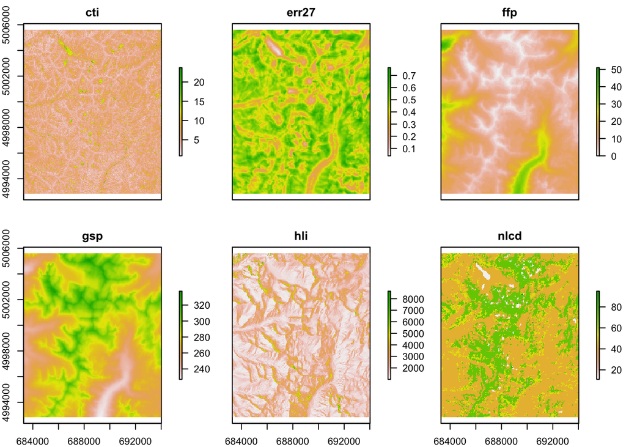

```r
plot(RALU.rasters.r)
```

Some layers seem to show a similar pattern. It is easy to calculate the correlation between quantitative raster layers. Here, the last layer ‘ncld’, is in fact categorical (land cover type), and it’s correlation here is meaningless.

```r
layerStats(RALU.rasters.r, 'pearson', na.rm=T)
```

```
## $`pearson correlation coefficient`
##              cti       err27         ffp         gsp         hli
## cti    1.0000000 -0.25442672  0.12264734 -0.14029572 -0.30501483
## err27 -0.2544267  1.00000000 -0.23467075  0.21403415  0.07724426
## ffp    0.1226473 -0.23467075  1.00000000 -0.95144256 -0.07567975
## gsp   -0.1402957  0.21403415 -0.95144256  1.00000000  0.09520075
## hli   -0.3050148  0.07724426 -0.07567975  0.09520075  1.00000000
## nlcd  -0.1807878  0.12562961 -0.32975610  0.37653635  0.24655404
##             nlcd
## cti   -0.1807878
## err27  0.1256296
## ffp   -0.3297561
## gsp    0.3765363
## hli    0.2465540
## nlcd   1.0000000
##
## $mean
##          cti        err27          ffp          gsp          hli
##    5.3386441    0.4509513   11.2037444  277.2211529 1938.3644530
##         nlcd
##   50.8191308
```

### b) Change color ramp, add sampling locations

Note: To learn about options for the ‘plot’ function for ‘raster’ objects, access the help file by typing ‘?plot’ and select ‘Plot a Raster* object’.

And we can add the sampling locations (if we plot only a single raster layer). Here we use ‘rev’ to reverse the color ramp for plotting raster layer ‘ffp’, and add the sites as white circles with black outlines.

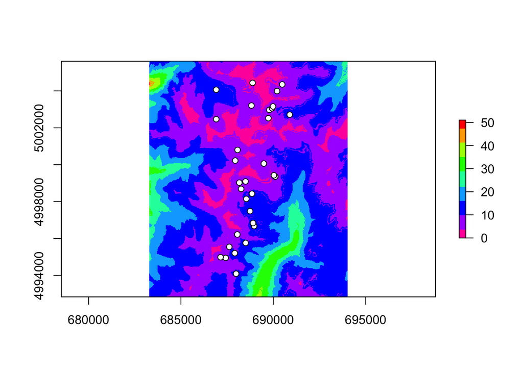

```r
plot(raster(RALU.rasters.r, layer="ffp"), col=rev(rainbow(9)))
points(RALU.site.sp, pch=21, col="black", bg="white")
```

### Extract raster values at sampling locations

The following code adds six variables to the data slot of RALU.site.sp. Technically we combine the columns of the existing data frame ‘RALU.site.sp’ with the new columns in a new dat frame with the same name.

R notices the difference in projection (CRS) between the sampling point data and the rasters and takes care of it, providing just a warning.

```r
RALU.site.sp@data <- data.frame(RALU.site.sp@data, extract(RALU.rasters.r, RALU.site.sp))
```

```
## Warning in .local(x, y, ...): Transforming SpatialPoints to the CRS of the
## Raster
```

What land cover type is assigned to the most sampling units? Let’s tabulate them.

Note: land cover types are coded by numbers. The most frequent type is ‘42’. Check here what the numbers mean: https://www.mrlc.gov/nlcd06_leg.php

```r
table(RALU.site.sp@data$nlcd)
```

```
##
## 11 12 42 52 71 90
##  3  1 21  1  4  1
```

## 4. Calculate patch-level and class-level landscape metrics

### a) Calculate class-level landscape metrics

Here we evaluate the spatial distribution of each cover type (class - this is not the same here as an object class). This is extremely fast in R. But first we’ll extract the ‘nlcd’ raster layer in a separate raster ‘NLCD’ to simplify the code.

```r
NLCD <- raster(RALU.rasters.r, layer="nlcd")
NLCD.class <- ClassStat(NLCD,cellsize=30)
```

For a list of all 37 metrics calculated, check the helpfile for ‘ClassStat’. Background information is available on the Fragstats webpage: http://www.umass.edu/landeco/research/fragstats/documents/Metrics/Metrics%20TOC.htm

```r
?ClassStat
```

### b) Calculate patch-level landscape metrics for ‘Evergreen Forest’

Calculating patch-level metrics is a little more involved, as we have to decide which cover type (class) to analyze, and then delinate patches for that cover type. Then we calculate statistics for each patch.

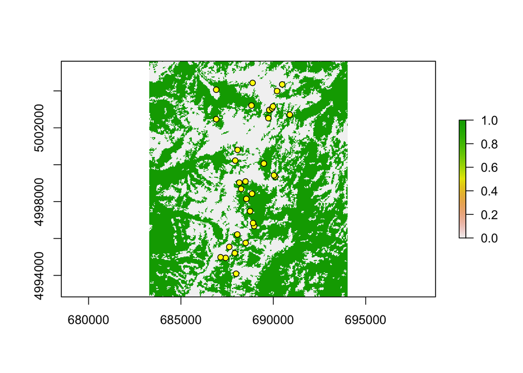

```r
plot(NLCD==42)
points(RALU.site.sp, pch=21, bg="yellow", col="black")
```

We use the function ‘ConnCompLabel’ to delineate patches (with the 8-neighbor rule, other rules are not implemented). This creates a new raster where the value in each cell is the new patch ID if forest (NLCD==42), or zero if not. Then we run ‘PatchStat’ on the new raster.

```r
ccl.mat <- ConnCompLabel(NLCD==42)
NLCD.patch <- PatchStat(ccl.mat,cellsize=30)
dim(NLCD.patch)
```

```
## [1] 223  12
```

This returns a list of 223 forest patches (rows) and 12 patch-level landscape metrics (columns). Let’s look at the first few patches. Patches differ greatly in size!

```r
head(NLCD.patch)
```

```
##   patchID n.cell n.core.cell n.edges.perimeter n.edges.internal     area
## 1       0  62447       34212             35760           214028 56202300
## 2       1      2           0                 6                2     1800
## 3       2  35332       24092             12898           128430 31798800
## 4       3     19           0                44               32    17100
## 5       4     39           5                46              110    35100
## 6       5      3           0                 8                4     2700
##   core.area perimeter perim.area.ratio shape.index frac.dim.index
## 1  30790800   1072800       0.01908819   35.760000       1.400937
## 2         0       180       0.10000000    1.000000       1.015714
## 3  21682800    386940       0.01216838   17.151596       1.329062
## 4         0      1320       0.07719298    2.444444       1.189944
## 5      4500      1380       0.03931624    1.769231       1.116677
## 6         0       240       0.08888889    1.000000       1.036411
##   core.area.index
## 1       0.5478566
## 2       0.0000000
## 3       0.6818748
## 4       0.0000000
## 5       0.1282051
## 6       0.0000000
```

For a list of the patch-level metrics calculated, check the helpfile.

```r
?PatchStat
```

Let’s add forest patch size to the RALU.site.sp data. First we need to get the patch ID at each sampling location, then its size.

```r
a <- extract.data(RALU.site.sp@coords, ccl.mat) # get patch IDs
a[a==0] <- NA
RALU.site.sp@data$ForestPatchSize <- NLCD.patch[a,"area"]
RALU.site.sp@data$ForestPatchSize[is.na(a)] <- 0
RALU.site.sp@data$ForestPatchSize
```

```
##  [1]  1800     0  1800     0   900 27000 27000 27000     0 27000 27000
## [12]  7200  7200     0     0 27000     0 27000  5400  1800     0 27000
## [23]  8100 27000     0     0  7200  1800     0 27000 15300
```

Plot a bubble map of forest patch size at each sampling location:

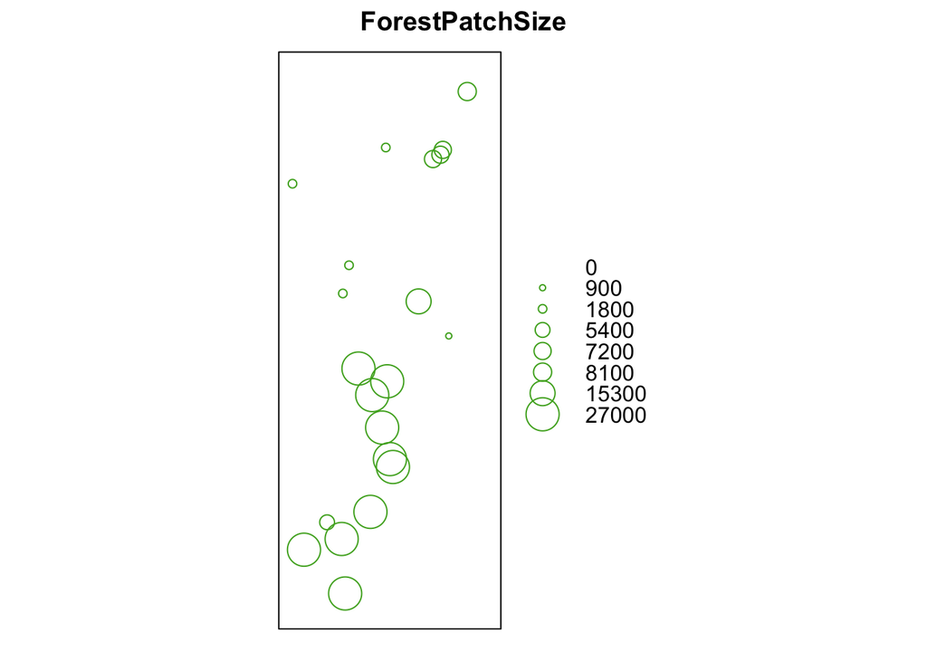

```r
bubble(RALU.site.sp, "ForestPatchSize", fill=FALSE, key.entries=as.numeric(names(table(RALU.site.sp@data$ForestPatchSize))))
```

## Extract landscape metrics at sampling locations.

### a) Calculate class-level metrics in buffer around sampling locations

First we define the buffer radius (in meters) and cell size:

```r
Radius <- 500    # Define buffer radius
Cellsize <- 30   # Indicate cell size in meters
```

Then we create a loop through all sampling locations, calculating class-level metrics for each one within its buffer. I’m afraid that explaining this code in detail would be too much for today.

```r
RALU.site.class <- list()

for(i in 1:length(RALU.site.sp))
{
  dist <- distanceFromPoints(NLCD, RALU.site.sp@coords[i,])
  test <- dist
  test[test < Cellsize] <- 1
  test[test > 1] <- NA
  test.buffer <- buffer(test, Radius)
  test2 <- NLCD * test.buffer
  #plot(test2) # Just checking: plot buffer
  RALU.site.class[[i]] <- ClassStat(test2,cellsize=30)
}
names(RALU.site.class) <- RALU.site.sp@data$SiteName

# Make sure all sites list all cover types, even if they are absent from buffer:
class.ID <- levels(as.factor(NLCD))[[1]]
RALU.site.class <- lapply(RALU.site.class, function(ls) merge(class.ID, ls, all=TRUE, by.x="ID", by.y="class"))
```

### b) Extract landscape metric of choice for a single cover type (as vector)

Now we can extract any variable of interest for any cover type of interest. Here we’ll extract the percentage of (evergreen) forest within a 500 m radius around each site.

```r
# Extract variable 'prop.landscape' for cover type 42 (Evergreen Forest):
PercentForest500 <- unlist(lapply(RALU.site.class, function(ls) ls[ls$ID==42, "prop.landscape"]))
PercentForest500[is.na(PercentForest500)] <- 0
PercentForest500
```

```
##    AirplaneLake  BachelorMeadow  BarkingFoxLake    BirdbillLake
##       0.7945055       0.3929336       0.3811563       0.3103814
##         BobLake       CacheLake         DoeLake    EggWhiteLake
##       0.3843683       0.8463983       0.7012848       0.8644068
##      ElenasLake        FawnLake    FrogPondLake     GentianLake
##       0.1059957       0.7248394       0.9218415       0.3715203
##    GentianPonds      GoldenLake      GreggsLake    InandOutLake
##       0.3601695       0.3029979       0.3029661       0.6122881
##      MeadowLake       MooseLake   Mt.WilsonLake       NopezLake
##       0.6220557       0.5571429       0.3415418       0.6790254
##     ParagonLake  ParagonWetland     PotholeLake    RamshornLake
##       0.4802198       0.3222698       0.2404661       0.5010989
##  ShipIslandLake     SkyhighLake StockingCapLake    Terrace1Lake
##       0.6359743       0.3276231       0.3104925       0.3062099
##      TobiasLake   WalkaboutLake     WelcomeLake
##       0.4470339       0.3230932       0.6875000
```

### c) Extract landscape metric of choice for all cover types (as data frame)

To extract the landscape metric ‘prop.landscape’ for all cover types as a data.frame (one column per cover type), use this code.

We’ll define column names combining ‘Prop’ for ‘proportion of landscape’, ‘500’ to indicate the 500 m buffer radius, and the ID of each cover type.

```r
tmp <- Reduce(rbind,lapply(RALU.site.class, function(ls) ls[, "prop.landscape"]))
dimnames(tmp) <- list(row.names=names(RALU.site.class),
                      col.names=paste("Prop.500", class.ID$ID, sep="."))
tmp[is.na(tmp)] <- 0
RALU.prop.landscape500 <- as.data.frame(tmp)
head(RALU.prop.landscape500)
```

```
##                Prop.500.11 Prop.500.12 Prop.500.31 Prop.500.42 Prop.500.52
## AirplaneLake    0.07912088 0.000000000  0.00000000   0.7945055  0.01098901
## BachelorMeadow  0.03961456 0.003211991  0.00856531   0.3929336  0.05674518
## BarkingFoxLake  0.01605996 0.000000000  0.01284797   0.3811563  0.14561028
## BirdbillLake    0.00000000 0.019067797  0.00000000   0.3103814  0.03389831
## BobLake         0.00000000 0.000000000  0.00000000   0.3843683  0.12740899
## CacheLake       0.03601695 0.000000000  0.00000000   0.8463983  0.03707627
##                Prop.500.71 Prop.500.90 Prop.500.95
## AirplaneLake    0.11538462  0.00000000 0.000000000
## BachelorMeadow  0.49250535  0.00000000 0.006423983
## BarkingFoxLake  0.44432548  0.00000000 0.000000000
## BirdbillLake    0.62288136  0.00529661 0.008474576
## BobLake         0.48822270  0.00000000 0.000000000
## CacheLake       0.08050847  0.00000000 0.000000000
```

### c) Append to site data set

```r
RALU.site.sp@data <- data.frame(RALU.site.sp@data, RALU.prop.landscape500)
```

Note: check this week’s bonus material if you want to see how to use the new ‘sf’ library for spatial data, and how to export the site data to an shapefile that you can import into a GIS.